# 20. Производная основных элементарых функций

1. $ c' = 0 $, т.к. $ \Delta c = 0 $
2. $ x' = 1 $, т.к. для $ f(x) = x: \lim\limits_{\Delta x \to 0} \frac{\Delta f}{\Delta x} = \lim\limits_{\Delta x \to 0} \frac{\Delta x}{\Delta x} = 1 $
3. $ f(x) = e^x \forall x \in \mathbb{R}. \lim\limits_{\Delta x \to 0} \frac{f(x_0 + \Delta x) - f(x)}{\Delta x} = \lim\limits_{\Delta x \to 0} \frac{e^{x_0 + \Delta x} - e^{x_0}}{\Delta x} = e^{x_0} \cdot \lim\limits_{\Delta x \to 0} \frac{e^{\Delta x} - 1}{\Delta x} = e^{x_0} $  
   $ (a^x)' = (e^{x ln \ a})' = e^{x ln \ a}(x ln \ a)' = a^x ln \ a $, поскольку $ cf(x)' = c'f(x) + cf'(x) = cf'(x)) $
4. $ (log_a x)' = \frac{1}{(a^y)'} $ (производная обратной функции) $ = \frac{1}{a^y \cdot ln \ a} = \frac{1}{x \cdot ln \ a}, x > 0 $
5. $ \alpha \neq 0, (x^\alpha)' = (e^{\alpha \cdot ln \ x})' = x^\alpha \cdot (\alpha \cdot ln \ x)' = \alpha \cdot x^\alpha \cdot \frac{1}{x} = \alpha \cdot x^{\alpha - 1}, x > 0 $
6. $ f(x) = sin(x) $. Пусть $ x_0 \in \mathbb{R} $, тогда $ \lim\limits_{\Delta x \to 0} \frac{sin(x_0 + \Delta x) - sin(x_0)}{\Delta x} = \lim\limits_{\Delta x \to 0} \frac{2 \cdot sin(\frac{\Delta x}{2}) \cdot sin(x_0 + \frac{\Delta x}{2})}{\Delta x} = \lim\limits_{\Delta x \to 0} \frac{sin(\frac{\Delta x}{2})}{\Delta x} cos(x + \frac{\Delta x}{2}) = cos(x_0)$
7. $ (cos \ x)' = (sin(\frac{\pi}{2} - x))' = cos(\frac{\pi}{2} - x) (\frac{\pi}{2} - x)' = -sin(x) $
8. $ (tg(x))' = \frac{sin'(x)cos(x) - cos'(x)sin(x)}{cos^2 x} = \frac{cos^2 x + sin^2 x}{xos^2 x} = \frac{1}{cos^2 x}, x \neq \frac{\pi}{2} + \pi n, n \in \mathbb{Z} $
9. $ (ctg(x))' = - \frac{1}{sin^2 x} $
10. $ (arcsin \ x)' = \frac{1}{(sin y)'} = \frac{1}{cos \ y} = \frac{1}{\sqrt{1 - x^2}} $  
    Упр. : доказать, что производная $ arcsin \ x $ обращается в $ \infty $, если $ x = \pm 1 $
11. Т.к. $ arccos \ x + arcsin \ x = \frac{\pi}{2} $, то $ (arccos \ x)' = (\frac{\pi}{2} - arcsin \ x)' = - \frac{1}{\sqrt{1 - x^2}}, -1 < x < 1 $
12. $ (arctg \ x)' = \frac{1}{(tg \ x)'} = cos^2 y = \frac{1}{1 + tg^2 x} = \frac{1}{1 + x^2} $
13. $ (arcctg \ x)' = (\frac{\pi}{2} - arcctg \ x)' = - \frac{1}{1 + x^2} $
14. $ (sh \ x)' = (\frac{e^x - e^{-x}}{2})' = \frac{e^x + e^{-x}}{2} = ch \ x $
15. $ (ch \ x)' = sh \ x $
16. $ (th \ x)' = (\frac{sh \ x}{ch \ x})' = \frac{(sh \ x)' ch \ x - (ch \ x)' sh \ x}{ch^2 x} = \frac{1}{ch^2 x} $
17. $ (cth \ x)' = (\frac{ch \ x}{sh \ x})' = \frac{(ch \ x)' sh \ x - (sh \ x)' ch \ x}{sh^2 x} = -\frac{1}{sh^2 x} $

# 21. Дифференциал функции

Пусть функция $ f $ дифференцируема в точке $ x_0 $. Тогда её приращение предстваляется в виде $ \Delta f = f'(x_0)\Delta x + \overline{o}(\Delta x), \Delta x \to 0 $.

Определение 1. Выражение $ f'(x_0)\Delta x $ называется дифференциалом (первым) функции $ f $ в точке $ x_0 $, соответствующим приращению аргумента $ \Delta x $. Обозначается $ df|^{x \to x_0} = f(x_0)\Delta x $

Звмечание: При фиксировании значения $ x_0 $, дифференциал - это линейная функция с аргументом $ x_0 $. Говорят, что дифференциал - главная линейная часть приращения функции $ \Delta f $ в точке $ x_0 $.

Пусть $ H $ лежит на касательной, проведённой к графику $ y = f(x) $ в точке $ M $; абсцисса точки $ H $ равна $ x_0 + \Delta x $. Тогда ордината $ y_H = f'(x_0)(x_H - x_0) + f(x_0) = f'(x_0)\Delta x + f(x_0) \Rightarrow H(x_0 + \Delta x, f'(x_0)\Delta x + f(x_0)) $. Тогда $ NP = f(x + \Delta x) - f(x_0) = \Delta x $ - приращение функции. $ HP = f'(x_0)\Delta x + f(x_0) - f(x_0) = f'(x_0) \Delta x $ - дифференциал функции $ f $. Таким образом, геометрический дифференциал - это приращение касательной, соответсвующее приращению фргумента $ \Delta x $.

Замечение. 1) Поскольку $ \Delta f = df + \overline{o}(\Delta x), \Delta x \to 0 $, то $ \frac{\Delta f - df}{\Delta x} = \overline{o}(0), \Delta x \to 0 \Rightarrow \Delta f = df $ при малых $ \Delta x $.

Например, вычислим примерно $ \sqrt[4]{1.05} $  
$ f(x) = x^{1/4}, x_0 = 1, \Delta x = 0.05 $. Тогда $ f(x_0 + \Delta x) - f(x_0) = \sqrt[4]{1.05} - 1 = df|_{x_0} = f'(x_0)\Delta x = \frac{1}{4} x^{-3/4}\cdot 0.05 = 0.0125 \Rightarrow \sqrt[4]{1.05} = 1.0125 $

### Теорема 1. Инвариантность формы первого дифференциала

Пусть $ f $ дифференцируема в точке $ x_0 $. Её первый дифференциал имеет вид $ df|_{x = x_0} = f'(x_0)dx$б независимо от того, является $ x $ независимой переменной, или функцией аргумента $ t $.

### Доказательство

Из замечания следует, что если $ x $ - независимая переменная, то $ \delta x = df \Rightarrow df|_{x = x_0} = f'(x_0)\Delta x = f'(x_0)dx $.

Пусть теперь $ x = \phi(t) $, $ \phi $ дифференцируема в точке $ t_0, \phi(t_0) = x_0 $. Тогда $ df|_{x=x_0} = (f(\phi(t)))'|_{t = t_0} \cdot \Delta t = f'(x_0)\phi(t_0) \Delta t = f'(x_0)dx $

# 22. Производные и дифференциалы высших порядков

Пусть $ f $ определена на $ (a, b), x_0 \in (a, b) $

Определение 1. Пусть $ f $ определена в каждой точкке отрезка $ (a, b) $, тогда на $ (a, b) $ определена функция $ f'(x) $. Если функция $ f'(x) $ дифференцируема в точке $ x_0 $, то её производная в этой точке называется второй производной (производной второго порядка) функции $ f $ в точке $ x_0 $. Пишут $ f''(x_0) = (f'(x_0)'|_{x = x_0}) $ или $ \frac{d^2f}{dx^2}|_{x = x_0} $

Замечание: Из теоремы об инфвариантнойсти функции первого дифференциала видно, что обозначение для первой производной: $ f'(x_0) = \frac{df}{dx}|_{x = x_0} $ - не просто обозначаение, а отношение дифференциалов.

Аналогично $ n $-ая производная функции $ f $ (производная $n$-го порядка) в точке $ x_0 f^{(n)}(x_0) = (f^{(n - 1)})'|_{x=x_0} $. Обозначается также $ \frac{d^nf}{dx^n}|_{x = x_0} $

Замечание:  
1) Если функция $ f $ имеет все производные по порядка $ n $ вклюсительно в точке $ x_0 $ (на множестве $ A $), то будем говорить, что $ f n $ раз дифференцируема в точке $ x_0 $ (на множестве $ A $)

2) По определению полодим $ f^{(0)}(x) = f(x) $

### Производные высших порядков некоторых элементарных функций

1. $ (e^x)^(n) = e^x; (a^x)^{(n)} = (ln \ a)^{(n)} \cdot a^x $
2. $ (x^\alpha)^{(n)} = \alpha \cdot (\alpha - 1) \dots (\alpha - n + n) x^{\alpha - n} $. В частности, пусть $ m \in \mathbb{N} $. Тогда $$ (x^m)^{(n)} = \begin{cases} \frac{m!}{(n - m)!}x^{m - n} &, n \leqslant m \\ 0 &, n > m \end{cases} $$
3. $ (ln \ x)^{(n)} = \frac{(-1)^{n - 1} (n - 1)!}{x^n} $  
   $ \dots $

### Формула Лейбница

Пусть $ f, g $ дифференцируемы в точке $ x_0 $. Тогда $ (f \cdot g)^{(n)}|_{x = x_0} = \sum\limits_{k = 0}^n C_n^k f^{(k - k)}(x_o)g^{(k)}(x_0) $

### Доказательство

$ (f \cdot g)|_{x = x_0} = C_1^0 f'(x_0)g(x_0) + c_1^1 f(x_0)g(x_0)= f'(x_0)g(x_0) + f(x_0)g'(x_0) $

Пусть верно для $ n $, докажем для $ n + 1 $:

$ (C^0_n f^{(n)}(x_0)g^{(0)}(x_0) + C^1_n f^{(n - 1)}(x_0)g^{(1)}(x_0) + \dots + C^n_n f^{(0)}(x_0)g^{(n)}(x_0))' = \dots = \\ C^0_{n + 2} f^{(n + 1)}(x_0)g^{(0)}(x_0) + (C^0_n + C^1_n) f^{(n)}(x_0)g^{(0)}(x_0) + \dots + C^n_n f^{(0)}(x_0)g^{(0)}(x_0) = \sum\limits_{k = 0}^n C_n^k f^{(k - k)}(x_o)g^{(k)}(x_0) $

Определение 2. Пусть функция $ f $ дифференцируема на интервале $ (a, b), x_0 \in (a, b) $. Положим в формуле для первого дифференциала: $ \Delta x = h $, тогда функция $ df= f'(x) \cdot h $ определена на $ (a, b) $. Если функция $ f $ дважды дифференцируема в точке $ x_0 $, то функция $ df $ дифференцируема в точке $ x_0 $, причём $ d(df)|_{x=x_0} = f''(x_0)h \Delta x $. Положим $ \Delta x = h = dx $, тогда полученное выражение $ d^2 f |_{x = x_0} = d(df) |_{x = x_0} = f''(x_0)dx^2$ называется вторым дифференциалом функции $ f $ в точке $ x_0 $.

Замечание:

$ d^2 x $ - второй дифференциал функции $ x $  
$ dx^2 = (dx)^2 $ - $ dx $ в квадрате, т.е. $ dx \cdot dx $

Аналогично, если $ f n $ раз дифференцируема в точке $ x_0 $, то $ d^nf|_{x = x_0} = d(d^{n - 1}f)|_{x=x_0} = f^{n}(x_0)dx_n $ - дифференциал $n$-го порядка функции $ f $ в точке $ x_0 $

Замечание:

1) Дифференциалы порядка $ n \geqslant 2 $ уже не обладают, вообще говоря, свойством инвариантности формы.  
Пусть $ x = \phi(t) $, тогда $ d^2f = d(df) = d(f'(x)\phi(t)dt) = (f'(x) \cdot \phi(t)dt)'_tdt = \dots = f''(x)dx^2 + f'(x)d^2x $  
Если $ x $ - независимая переменная, то $ d^2x = 0 $

2) Пусть $ f, g n $ раз дифференцируемы в точке $ x_0 $, $ x $ - независимая переменная. Тогда $ d''(fg)|_{x = x_0} = (fg)^n|_{x = x_0}dx^n = \sum\limits_{k = 0}^n C_n^k f^{(n - k)}(x_0)g^{(k)}(x_0) dx^n = \sum\limits_{k = 0}^n C_n^k f^{(n - k)}(x_0) dx^{n -k} \ g^{(k)}(x_0) dx^k = \sum\limits_{k = 0}^n C_n^k d^{n - k}f|_{x_0} \ d^k g|_{x_0}$

### Произведение функций, заданных параметрически.

Определение 1. ПУсть $ \phi: T \to X, \psi: T \to Y $. Если $ \phi $ - биекция, то $ \exists \phi^{-1}: X \to T $. Тогда нужно положить $ f = \phi(\phi^{-1}): X \to Y $. В таком случае говорят, что функция $ f $ задана параметрически: $ \begin{cases} x = \phi(t) \\ y = \phi(t) \end{cases}, t \ in T $

Пример: $ \begin{cases} x = \cos(t) \\ y = \sin(t) \end{cases}, t \ in [0, \pi] $

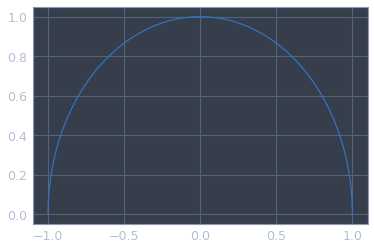

```python
import numpy as np
import matplotlib.pyplot as plt

t = np.linspace(0, np.pi, 200)
x = np.cos(t)
y = np.sin(t)

plt.plot(x, y)
plt.show()
```

### Теорема 2

Пусть функции $ \phi(t), \psi(t) $ дважды дифференцируемы в точке $ t_0, \phi'(t_0) \neq 0 $. Тогда функция $ f: \begin{cases} x = \phi(t) \\ y = \phi(t) \end{cases}$ дважды дифференцруема в точке $ x_0 = \phi(t_0) $, причём $ f'(x_0) = \frac{\psi'(t_0)}{\phi'(t_0)}, f''(x_0) = \frac{\psi''(t_0)\phi'(t_0) - \psi'(t_0)\phi''(t_0)}{(\phi'(t_0))^3} $

### Доказательство

$ f'(x_0) = \frac{df}{dx}|_{x = x_0} = \frac{\psi'(t_0)dt}{\phi'(t_0)dt} = \frac{\psi'(t_0)}{\phi'(t_0)} $

$ f''(x_0) = (f'(x))' |_{x = x_0} = (\frac{\psi'(t_0)}{\phi'(t_0)})' |_{x = x_0} = (\frac{\psi'(t_0)}{\phi'(t_0)})_t' \cdot t_x'|_{x = x_0} = \frac{\psi''(t_0)\phi'(t_0) - \psi'(t_0)\phi''(t_0)}{(\phi'(t_0))^2} \cdot \frac{1}{\phi'(x)} = \frac{\psi''(t_0)\phi'(t_0) - \psi'(t_0)\phi''(t_0)}{(\phi'(t_0))^3}$

# 23. Очевидные теоремы о дифференцируемых функциях

Пусть $ f $ определена в окрестности ирчки $ x_0 $.

Определение 1. Функция $ f $ возрастает (убывает) в точке $ x_0 $, если $ \exists \delta > 0: $ $ f(x) < f(x_0) \forall x \in (x_0 - \delta, x_0) \\ f(x) > f(x_0) \forall x \in (x_0, x_0 + \delta) $ (наоборот для убываения).

$ f $ не убывает (не возрастает) в точке $ x_0 $, если знаки в соответствующих неравенствах нестрогие.

Определение 2. $ f $ имеет в точке $ x_0 $ локальный максимум (минимум), если $ \exists \delta > 0: f'(x_0) \geqslant f(x) (f'(x_0) \leqslant f(x)) \forall x \in \dot B_\sigma(x_0) $. Такие точки назваются точками локального экстремума.

Если $ f(x_0) > f(x) \forall x \in \dot B_\delta(x_0) $, то экстремум строгий.

### Теорема 1 - достаточное условие возрастания

Если $ f $ дифференцируема в точке $ x_0 $, и $ f'(x_0) > 0 (< 0) $, то $ f $ возрастает (убывает) в точке $ x_0 $

### Доказательство

Пусть $ f'(x_0) > 0 $. Полодим в определение производной через предел $ \varepsilon = \frac{f'(x_0)}{2} $. Тогда $ \exists \sigma > 0, \forall x \in \dot B_\delta (x_0): |\frac{f(x) - f(x_0)}{x - x_0} -f'(x_0)| < \frac{f'(x_0)}{2} \Rightarrow \frac{f(x) - f(x_0)}{x - x_0} > frac{f'(x_0)}{2} > 0 \forall x \in \dot B_\sigma(x_0) $/. Значит $ f(x) - f(x_0) $ и $ x - x_0 $ имеют одинаковый знак и $ f $ возрастает в точке $ x_0 $.

### Теорема 2 - Ферма, необходимое условие экстремума

Пусть $ x_0 $ - точка локального экстремума функции $ f $. Если $ f $ дифференцируема в точке $ x_0 $, то $ f'(x_0) = 0 $

### Доказательство

Если $ f'(x_0) > 0 (< 0) $, то $ f $ возрастает (убывает) в точке $ x_0 \Rightarrow $ это - не точка экстремума